# R package coga: Convolution of Gamma Distributions

Chaoran Hu

2017-11-05

# Introduction

This R package coga can help you to calculate density and distribution function of convolution of gamma distributions. The convolution of gamma distributions is the sum of series of independent gamma distributions. The algorithm of this package comes from Moschopoulos Peter G. (1985). The R coda in this vignette also can be considered as useful examples.

# Algorithm

Assume that we have several random variables, $X_1, ..., X_n$, and all random variables follow gamma distribution independently with shape parameters $\alpha_i$ and scale parameters $\beta_i$, where $i = 1, ..., n$. Then, the density of $Y = X_1 + ... + X_n$ can be expressed as:

$$g(y) = C \sum_{k=0}^{\infty} \lambda_k y^{\rho + k - 1} e^{-y/\beta_1} / (\Gamma(\rho + k) \beta_{1}^{\rho + k})$$

And the distribution function $G(w)=Pr(Y<w)$ is expressed as:

$$G(w) = C \sum_{k=0}^{\infty} \lambda_k \int_{0}^{w} (y^{\rho + k - 1} e^{-y/\beta_1} / (\Gamma(\rho + k) \beta_{1}^{\rho + k})) dy$$

The integrate in this formula is incomplete gamma function and can be calculated by distribution function of gamma distribution.

More details about this algorithm can be found in paper of Moschopoulos Peter G. (1985).

# Correctness

Assume that we have two random variables, $X_1$ and $X_2$, where $X_1$ is a gamma distribution with shape parameter $3$, and rate parameter $2$, and $X_2$ is a gamma distribution with shape parameter $4$, and rate parameter $3$. The density and distribution funciton of $Y = X_1 + X_2$ will be calculated.

Correctness check for density function:

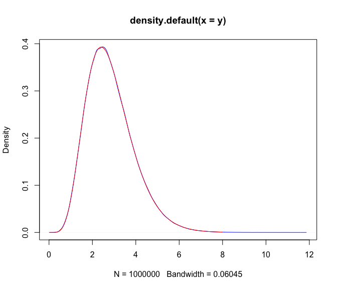

```r
y <- rcoga(1000000, c(3,4), c(2,3))
grid <- seq(0, 8, length.out=1000)
pdf <- dcoga(grid, shape=c(3, 4), rate=c(2, 3))

plot(density(y), col="blue")
lines(grid, pdf, col="red")
```

Correctness check for distribution function:

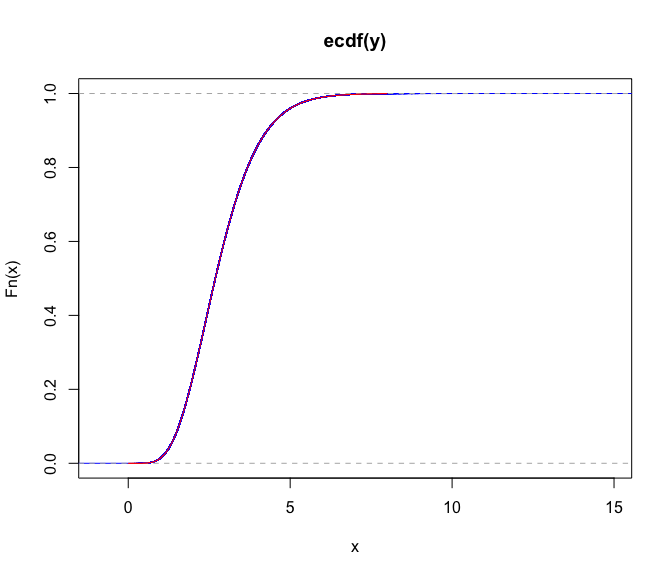

```r
y <- rcoga(1000000, c(3,4), c(2,3))
grid <- seq(0, 8, length.out=1000)
cdf <- pcoga(grid, shape=c(3, 4), rate=c(2, 3))

plot(ecdf(y), col="blue")
lines(grid, cdf, col="red")
```

# Speed

The ‘dcoga’ and ‘pcoga’ functions in this package ‘coga’ is based on Cpp code. The following experiment shows the advantage of Cpp code, which runs on a Intel(R) Core(TM) i7-4870HQ CPU @ 2.50GHz computer.

```r
grid <- seq(0, 15, length.out=10)

microbenchmark::microbenchmark(
    dcoga(grid, shape=c(3,4,5), rate=c(2,3,4)),
    coga:::dcoga.R(grid, shape=c(3,4,5), rate=c(2,3,4)),
    pcoga(grid, shape=c(3,4,5), rate=c(2,3,4)),
    coga:::pcoga.R(grid, shape=c(3,4,5), rate=c(2,3,4))
)
```

```
## Unit: milliseconds
##                                                         expr       min
##           dcoga(grid, shape = c(3, 4, 5), rate = c(2, 3, 4))  3.660213
##  coga:::dcoga.R(grid, shape = c(3, 4, 5), rate = c(2, 3, 4)) 30.663710
##           pcoga(grid, shape = c(3, 4, 5), rate = c(2, 3, 4))  4.050537
##  coga:::pcoga.R(grid, shape = c(3, 4, 5), rate = c(2, 3, 4)) 37.169637
##         lq      mean    median        uq       max neval
##   4.556770  5.791364  4.877600  5.282755  51.28440   100
##  34.010727 40.135430 35.882988 38.409521  76.62929   100
##   4.924504  7.720909  5.277665  5.925103  50.83647   100
##  41.264243 54.756851 44.886557 76.992697 113.38901   100
```

Note: In this example, ‘dcoga.R’, and ‘pcoga.R’ are the R version functions for density, and distribution functions of convolution of gamma distributions. We do not put these two R functions as export functions in package ‘coga’, but you can still use them by ‘coga:::dcoga’, and ‘coga:::pcoga’.

The convolution of two gamma distributions is a special situation of convolution of gamma distributions. The functions ‘dcoga2dim’ and ‘pcoga2dim’ can solve this problem with higher efficiency (they are much more faster than the general functions, ‘dcoga’ and ‘pcoga’.)

```r
grid <- seq(0, 15, length.out=100)

microbenchmark::microbenchmark(
    dcoga(grid, shape=c(3,4), rate=c(2,3)),
    dcoga2dim(grid, 3, 4, 2, 3),
    pcoga(grid, shape=c(3,4), rate=c(2,3)),
    pcoga2dim(grid, 3, 4, 2, 3))
```

```
## Unit: microseconds
##                                          expr       min         lq
##  dcoga(grid, shape = c(3, 4), rate = c(2, 3)) 35528.612 37317.1115
##                   dcoga2dim(grid, 3, 4, 2, 3)    49.702    53.8075
##  pcoga(grid, shape = c(3, 4), rate = c(2, 3)) 37544.710 39811.5785
##                   pcoga2dim(grid, 3, 4, 2, 3)  4208.064  4227.0410
##         mean    median        uq        max neval
##  53637.09087 58885.084 63120.044 126294.439   100
##     65.38235    65.122    67.687    141.934   100
##  56558.79096 61800.481 65640.738  80674.420   100
##   4461.62464  4241.235  4446.181   6206.607   100
```

# Parameters Recycling

Please take care of that R functions `dcoga`, `pcoga`, and `rcoga` in this package can handle different lengths of parameter `shape` and `rate` by recycling shorter parameter. That means that `dcoga(3, c(2,3), c(3,4,5,3,4))` and `dcoga(3, c(2,3,2,3,2), c(3,4,5,3,4))` will give the same result. If the length of the longer parameter is not a multiple of the length of shorter one, these three R functions will give a **Warning** message.

# References

[1] Moschopoulos, Peter G. “The distribution of the sum of independent gamma random variables.” Annals of the Institute of Statistical Mathematics 37.1 (1985): 541-544.

[2] Mathai, A.M.: Storage capacity of a dam with gamma type inputs. Ann. Inst. Statist.Math. 34, 591-597 (1982).